# Lab4

Joel Martin

10/11/2020

## Load Data and Libraries

```r
library(readxl)
library(tidyr)
library(dplyr)
```

```r
library(ggplot2)
defense <- read_excel('C:/Users/joelm/Documents/ISU Schoolwork/DS 202/ds202_lab4/ds202_lab4/cyclonesFootball2019.xlsx', sheet='Defensive')
offensive <- read_excel('C:/Users/joelm/Documents/ISU Schoolwork/DS 202/ds202_lab4/ds202_lab4/cyclonesFootball2019.xlsx', sheet='Offensive')
biography <- read_excel('C:/Users/joelm/Documents/ISU Schoolwork/DS 202/ds202_lab4/ds202_lab4/cyclonesFootball2019.xlsx', sheet='Biography')
```

## Part One: Cleaning Data

## Parts 1 - 3

```r
defClean <- defense
defClean$Name <- as.factor(defClean$Name)
defClean$Opponent_Opponent <- as.factor(defClean$Opponent_Opponent)
defClean$Tackles_Solo <- as.numeric(defClean$Tackles_Solo)
defClean$Tackles_ASST <- as.numeric(defClean$Tackles_ASST)
defClean$Tackles_TFL <- as.numeric(defClean$Tackles_TFL)
defClean$Tackles_Sack <- as.numeric(defClean$Tackles_Sack)
defClean$Turnover_FF <- as.numeric(defClean$Turnover_FF)
defClean$Turnover_FR <- as.numeric(defClean$Turnover_FR)
defClean$Turnover_INT <- as.numeric(defClean$Turnover_INT)
defClean$Pass_QBH <- as.numeric(defClean$Pass_QBH)
defClean$Pass_PB <- as.numeric(defClean$Pass_PB)

offClean <- offensive
offClean$Name <- as.factor(offClean$Name)
offClean$Opponent_Opponent <- as.factor(offClean$Opponent_Opponent)
offClean$Rushing_ATT <- as.numeric(offClean$Rushing_ATT)
offClean$Rushing_YDS <- as.numeric(offClean$Rushing_YDS)
offClean$Rushing_TD <- as.numeric(offClean$Rushing_TD)
offClean$Receiving_REC <- as.numeric(offClean$Receiving_REC)
offClean$Receiving_YDS <- as.numeric(offClean$Receiving_YDS)
offClean$Receiving_TD <- as.numeric(offClean$Receiving_TD)
offClean$`Passing_CMP-ATT` <- as.numeric(offClean$`Passing_CMP-ATT`)
```

```r
offClean$Passing_YDS <- as.numeric(offClean$Passing_YDS)
offClean$Passing_TD <- as.numeric(offClean$Passing_TD)
offClean$Passing_INT <- as.numeric(offClean$Passing_INT)

bioClean <- biography
bioClean$Name <- as.factor(bioClean$Name)
bioClean <- separate(bioClean, Height, c('feet', 'inches'))
bioClean$feet <- as.numeric(bioClean$feet)
bioClean$inches <- as.numeric(bioClean$inches)
bioClean$Height <- ((bioClean$feet * 30.48) + (bioClean$inches * 0.3048))
```

## Part two: Tidying

## Question 1

Pivoted the defClean dataframe using the stats columns and tried renaming the new column to stat however this created problems as R uses stat as a key word so I left the column as name which was the default.

```r
defCleanLongPiv <- pivot_longer(defClean, Tackles_Solo:Pass_PB)
```

## Question 2

Created a graph showing the distribution of defense skills.

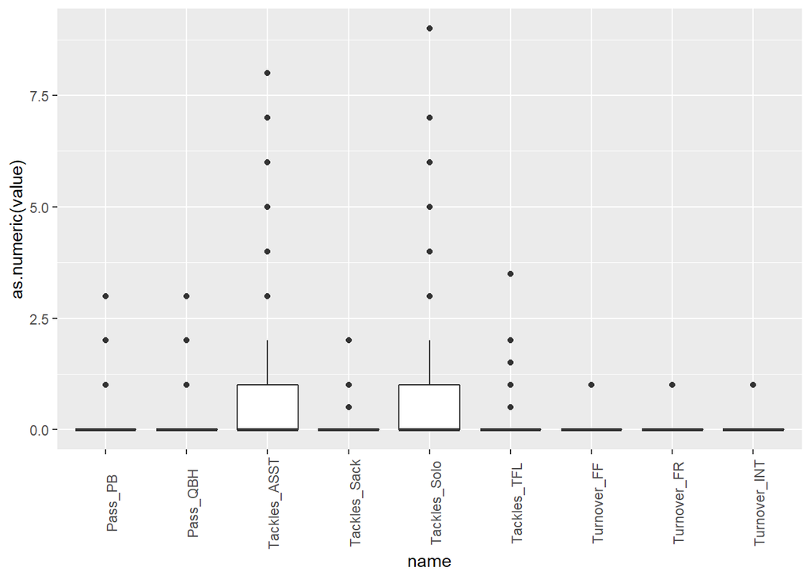

```r
ggplot(defCleanLongPiv, aes(x=name, y=as.numeric(value))) + geom_boxplot() + theme(axis.text.x = element_text(angle = 90))
```

Based on the graph, many of the defensive skills are rare however the rarest are Turnover FF, FR and INT.

## Question 3

Created a graph showing ISU solo tackles for each player for the Iowa and Notre Dame games. Used jitter to be able to better see where the data is falling.

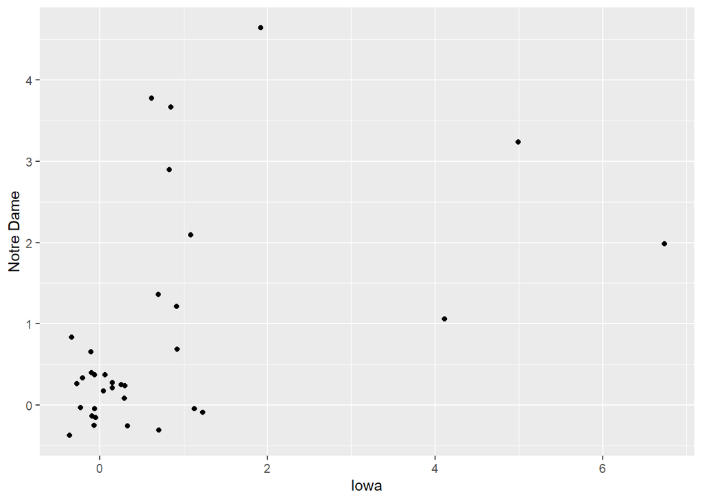

```r
tidying3 <- subset(defCleanLongPiv, (Opponent_Opponent == 'Iowa' | Opponent_Opponent == 'Notre Dame') & name == 'Tackles_Solo')
tidying3 <- pivot_wider(tidying3, Name, names_from = Opponent_Opponent, values_from = value)
ggplot(tidying3, aes(x=as.numeric(Iowa), y=as.numeric(tidying3$'Notre Dame'))) + geom_jitter() + xlab('Iowa') + ylab('Notre Dame')
```

Based on the graph it appears that for both games there is a large concentration of zero solo tackles. However overall it appears that there where more solo tackles against Notre Dame and therefore ISU had a better defense in the Notre Dame game versus the Iowa game.

## Question 4 & 5

Separated Hometown column in bioClean dataframe into two columns city and state. Printed the first few rows of these columns and then created a graph showing how many players are from each state as well as a summary.

```r
bioClean <- separate(bioClean, Hometown, c('City', 'State'), sep = ',')
tidying4 <- subset(bioClean, select = City:State)
head(tidying4)
```

```
## # A tibble: 6 x 2
##   City          State
##   <chr>         <chr>
## 1 Cedar Rapids  " Iowa"
## 2 Nixa          " Mo."
## 3 Seffner       " Fla."
## 4 Naperville    " Ill."
## 5 Grand Prairie " Texas"
## 6 Clarksdale    " Miss."
```

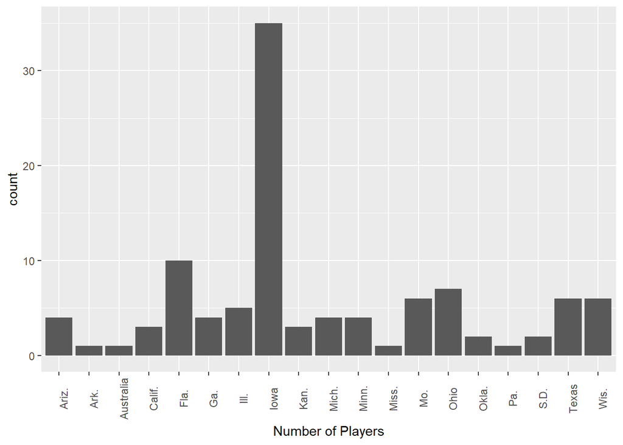

```r
ggplot(bioClean, aes(x = State)) + geom_bar() + theme(axis.text.x = element_text(angle = 90)) + xlab('Number of Players')
```

```r
summary(factor(bioClean$State))
```

```
##      Ariz.       Ark.  Australia     Calif.       Fla.        Ga.       Ill.
##          4          1          1          3         10          4          5
##       Iowa       Kan.      Mich.      Minn.      Miss.        Mo.       Ohio
##         35          3          4          4          1          6          7
##      Okla.        Pa.       S.D.      Texas       Wis.
##          2          1          2          6          6
```

## Part Three: Joing Data Frames

## Question 1

Joined the offClean and DefClean dataframes as well as the bioClean datatframe to see which state each player came from. Some are NA as their bio info has not yet been added to the biography table.

```r
statesFrom <- full_join(pivot_wider(offClean, Name), pivot_wider(defClean, Name))
bioStates <- select(bioClean, c(Name, State))
statesFrom <- left_join(statesFrom, bioStates, by = 'Name')
summary(factor(statesFrom$State))
```

```
##   Ariz.    Ark.  Calif.    Fla.     Ga.    Ill.    Iowa    Kan.   Mich.     Mo.
##       1       1       2       6       3       1       7       1       1       2
##    Ohio   Okla.   Texas    Wis.    NA's
##       4       2       3       2      16
```

## Question 2

Created a new column for total score for each player.

```r
ISUTeam <- full_join(offClean, defClean)
ISUTeam[is.na(ISUTeam)] <- 0
ISUTeam$Score <- rowSums(ISUTeam[,3:21])
ISUTeam <- group_by(ISUTeam, Name)
ISUTeam <- summarise(ISUTeam, TotalScore = sum(Score))
```

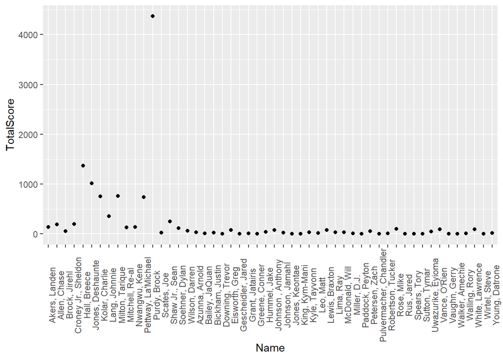

```r
ggplot(ISUTeam, aes(x=Name, y=TotalScore)) + geom_point() + theme(axis.text.x = element_text(angle = 90))
```

Brock’s score is significantly higher than anyone else’s score. Brock’s score of about 4368 is about 3 times higher than the next highest score which is Breece Hall’s score of about 1369.

## Question 3

Added and cleaned the 2018 ISU Football data like I cleaned the 2019 data. Created an ISU 2018 Team dataframe and gave each player a score like previous question. Then I merged the 2 team dataframes together into 1 dataframe to compare the players scores between the 2 years.

```r
defense2018 <- read_excel('C:/Users/joelm/Documents/ISU Schoolwork/DS 202/ds202_lab4/ds202_lab4/cyclonesFootball2018.xlsx', sheet='Defensive')
offensive2018 <- read_excel('C:/Users/joelm/Documents/ISU Schoolwork/DS 202/ds202_lab4/ds202_lab4/cyclonesFootball2018.xlsx', sheet='Offensive')
defClean2018 <- defense2018
defClean2018$Name <- as.factor(defClean2018$Name)
defClean2018$Opponent_Opponent <- as.factor(defClean2018$Opponent_Opponent)
defClean2018$Tackles_Solo <- as.numeric(defClean2018$Tackles_Solo)
defClean2018$Tackles_ASST <- as.numeric(defClean2018$Tackles_ASST)
defClean2018$Tackles_TFL <- as.numeric(defClean2018$Tackles_TFL)
defClean2018$Tackles_Sack <- as.numeric(defClean2018$Tackles_Sack)
defClean2018$Turnover_FF <- as.numeric(defClean2018$Turnover_FF)
defClean2018$Turnover_FR <- as.numeric(defClean2018$Turnover_FR)
defClean2018$Turnover_INT <- as.numeric(defClean2018$Turnover_INT)
defClean2018$Pass_QBH <- as.numeric(defClean2018$Pass_QBH)
defClean2018$Pass_PB <- as.numeric(defClean2018$Pass_PB)

offClean2018 <- offensive2018
offClean2018$Name <- as.factor(offClean2018$Name)
offClean2018$Opponent_Opponent <- as.factor(offClean2018$Opponent_Opponent)
offClean2018$Rushing_ATT <- as.numeric(offClean2018$Rushing_ATT)
offClean2018$Rushing_YDS <- as.numeric(offClean2018$Rushing_YDS)
offClean2018$Rushing_TD <- as.numeric(offClean2018$Rushing_TD)
offClean2018$Receiving_REC <- as.numeric(offClean2018$Receiving_REC)
offClean2018$Receiving_YDS <- as.numeric(offClean2018$Receiving_YDS)
offClean2018$Receiving_TD <- as.numeric(offClean2018$Receiving_TD)
offClean2018$`Passing_CMP-ATT` <- as.numeric(offClean2018$`Passing_CMP-ATT`)
offClean2018$Passing_YDS <- as.numeric(offClean2018$Passing_YDS)
offClean2018$Passing_TD <- as.numeric(offClean2018$Passing_TD)
offClean2018$Passing_INT <- as.numeric(offClean2018$Passing_INT)

ISUTeam2018 <- full_join(offClean2018, defClean2018)
ISUTeam2018[is.na(ISUTeam2018)] <- 0
ISUTeam2018$Score <- rowSums(ISUTeam2018[,3:21])
ISUTeam2018 <- group_by(ISUTeam2018, Name)
ISUTeam2018 <- summarise(ISUTeam2018, TotalScore = sum(Score))
```

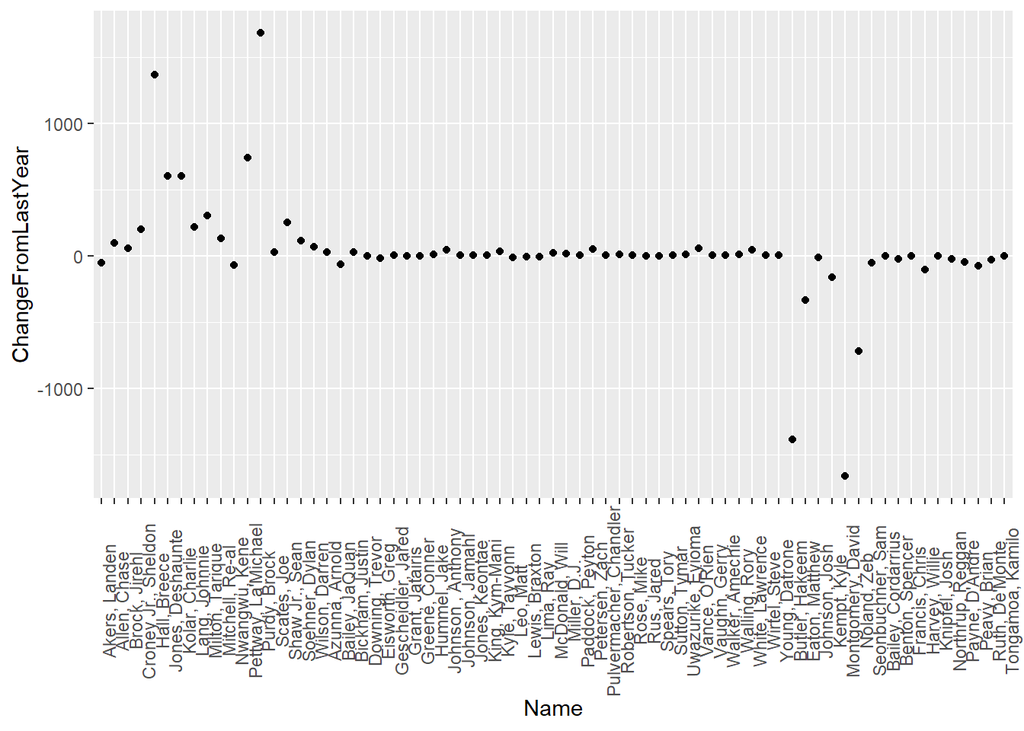

```r
ISUTeamCompare <- full_join(ISUTeam, ISUTeam2018, by = 'Name')
ISUTeamCompare[is.na(ISUTeamCompare)] <- 0
ISUTeamCompare <- rename(ISUTeamCompare, Score2019 = TotalScore.x, Score2018 = TotalScore.y)
ISUTeamCompare$ChangeFromLastYear <- ISUTeamCompare$Score2019 - ISUTeamCompare$Score2018
ggplot(ISUTeamCompare, aes(x = Name, y = ChangeFromLastYear)) + geom_point() + theme(axis.text.x = element_text(angle = 90))
```